# Analysis of Variation(ANOVA) AND PARAMETRIC TEST

MAKINI CALEB

2026-09-28

# setting a working directory

```r
setwd("C:/Users/ADMIN/OneDrive/Desktop/caleb makini")
```

# loading libraries

```r
library(dplyr)
library(tidyverse)
library(ggplot2)
```

# import data

```r
hg <- read.csv("gsssubset.csv")
head(hg)
```

```
  id    sex         degree   income  marital age height weight hrswrk
1  1   MALE       BACHELOR 60967.50 DIVORCED  53     72    190     60
2  2 FEMALE       BACHELOR 60967.50  MARRIED  26     60     97     40
3  4 FEMALE       BACHELOR 10161.25  MARRIED  56     68    160     20
4 14 FEMALE    HIGH SCHOOL 17551.25  MARRIED  40     65    156     37
5 16   MALE    HIGH SCHOOL 17551.25  MARRIED  56     NA    210      6
6 19   MALE LT HIGH SCHOOL 15703.75  MARRIED  51     68    170     NA
```

# one way Anova

## test whether there are significance differences btn group means

```r
data7 <- data.frame(group = factor(c("A", "A", "A", "B", "B", "B", "C", "C", "C")),
    value = c(5:13))
head(data7)
```

```
  group value
1     A     5
2     A     6
3     A     7
4     B     8
5     B     9
6     B    10
```

# perform 1 way ANOVA

## HO: there is no significance diffrence across the scores across the three groups

## H1: there is significance scores across the three groups

```r
one_anova <- aov(value ~ group, data = data7)
summary(one_anova)
```

```
            Df Sum Sq Mean Sq F value Pr(>F)
group        2     54      27      27  0.001 ***
Residuals    6      6       1
---
Signif. codes:  0 '***' 0.001 '**' 0.01 '*' 0.05 '.' 0.1 ' ' 1
```

# results

- since the p-value<5%, we reject null hypothesis and conclude that exist significance btn the 3 groups

# post-hoc test(turkey’s hsd) : identify which group differ significantly after a significant anova results

```r
turkey_results = TukeyHSD(one_anova)
print(turkey_results)
```

```
  Tukey multiple comparisons of means
    95% family-wise confidence level

Fit: aov(formula = value ~ group, data = data7)

$group
    diff       lwr      upr     p adj
B-A    3 0.4947644 5.505236 0.0242291
C-A    6 3.4947644 8.505236 0.0007942
C-B    3 0.4947644 5.505236 0.0242291
```

- b-a exist

# plot the results

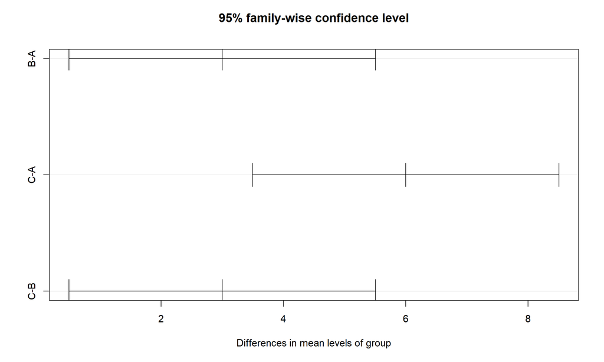

```r
plot(turkey_results)
```

# 2-way Anova

```r
data9 <- data.frame(factor1 = factor(c("X", "X", "X", "Y", "Y", "Y")), factor2 = factor(c("P",
    "Q", "R", "P", "Q", "R")), value1 = c(5:10))
head(data9)
```

```
  factor1 factor2 value1
1       X       P      5
2       X       Q      6
3       X       R      7
4       Y       P      8
5       Y       Q      9
6       Y       R     10
```

# perform 2 way anova

## H0: there is no significance difference on avarage income across factor 1

## H1: there is no significance difference on avarage income across factor 2

## H2: there is no significance difference on avarage income across the interaction

```r
anova_model1 <- lm(value1 ~ factor1 * factor2, data = data9)
anova_result <- anova(anova_model1)
print(anova_result)
```

```
Analysis of Variance Table

Response: value1
                Df Sum Sq Mean Sq F value Pr(>F)
factor1          1   13.5    13.5     NaN    NaN
factor2          2    4.0     2.0     NaN    NaN
factor1:factor2  2    0.0     0.0     NaN    NaN
Residuals        0    0.0     NaN
```

# using real data set

## H0: there is no significance difference on avarage income across gender

## H1: there is no significance difference on avarage income across marital status

## H2: there is no significance difference on avarage income across the interaction

```r
hg$marital <- as.factor(hg$marital)
hg$sex <- as.factor(hg$sex)
anova_model_data <- lm(income ~ sex * marital, data = hg)
anova_tway <- anova(anova_model_data)
print(anova_tway)
```

```
Analysis of Variance Table

Response: income
             Df     Sum Sq    Mean Sq F value    Pr(>F)
sex           1 8.7751e+10 8.7751e+10 84.1939 < 2.2e-16 ***
marital       4 5.8740e+10 1.4685e+10 14.0897 3.477e-11 ***
sex:marital   4 2.3753e+10 5.9382e+09  5.6975 0.0001555 ***
Residuals   984 1.0256e+12 1.0422e+09
---
Signif. codes:  0 '***' 0.001 '**' 0.01 '*' 0.05 '.' 0.1 ' ' 1
```

- the data is significance

# by degree

## H0: there is no significance difference on avarage income across degree

## H1: there is no significance difference on avarage income across marital status

## H2: there is no significance difference on avarage income across the interaction

```r
hg$marital <- as.factor(hg$marital)
hg$degree <- as.factor(hg$degree)
anova_model_data4 <- lm(income ~ degree * marital, data = hg)
anova_tway2 <- anova(anova_model_data4)
print(anova_tway2)
```

```
Analysis of Variance Table

Response: income
                Df     Sum Sq    Mean Sq F value    Pr(>F)
degree           4 2.1526e+11 5.3815e+10 56.7944 < 2.2e-16 ***
marital          4 4.4782e+10 1.1195e+10 11.8152 2.247e-09 ***
degree:marital  16 1.7599e+10 1.1000e+09  1.1609    0.2938
Residuals      969 9.1817e+11 9.4755e+08
---
Signif. codes:  0 '***' 0.001 '**' 0.01 '*' 0.05 '.' 0.1 ' ' 1
```

# non - parametric sets

## wilcoxon rank_sum test(mann-whitney u test): compare medians of 2 independent

```r
group00 <- c(5:7)
group000 <- c(8:10)
wilcon <- wilcox.test(group00, group000)
print(wilcon)
```

```
    Wilcoxon rank sum exact test

data:  group00 and group000
W = 0, p-value = 0.1
alternative hypothesis: true location shift is not equal to 0
```

- since the p-value>5%, we fail to reject null analysis and conclude that their is no difference significant btn median of group (00 and 000)

# kruskal-wallis test: compare median of more than one group

## H0: median value of A=B=C

## H1: median value of A!=B!=C

```r
data222 <- data.frame(group6 = factor(c("A", "A", "A", "B", "B", "B", "C", "C", "C")),
    value = c(5:13))
head(data222)
```

```
  group6 value
1      A     5
2      A     6
3      A     7
4      B     8
5      B     9
6      B    10
```

# kruskal-willis test

```r
kruskal_results <- kruskal.test(value ~ group6, data = data222)
print(kruskal_results)
```

```
    Kruskal-Wallis rank sum test

data:  value by group6
Kruskal-Wallis chi-squared = 7.2, df = 2, p-value = 0.02732
```

# using gsssubset

```r
kruskal_result2 <- kruskal.test(hg$income ~ hg$marital, data = data222)
print(kruskal_result2)
```

```
    Kruskal-Wallis rank sum test

data:  hg$income by hg$marital
Kruskal-Wallis chi-squared = 66.454, df = 4, p-value = 1.271e-13
```